# CSCI E-106:Assignment 10

### Due Date: December 7, 2020 at 7:20 pm EST

### Instructions

Students should submit their reports on Canvas. The report needs to clearly state what question is being solved, step-by-step walk-through solutions, and final answers clearly indicated. Please solve by hand where appropriate.

Please submit two files: (1) a R Markdown file (.Rmd extension) and (2) a PDF document, word, or html generated using knitr for the .Rmd file submitted in (1) where appropriate. Please, use RStudio Cloud for your solutions.

## Problem 1

Refer to the Cement Composition Data. The variables collected were the amount of tricalcium aluminate ($X_1$), the amount of tricalcium silicate ($X_2$), the amount of tetracalcium alumino ferrite ($X_3$), the amount of dicalcium silicate ($X_4$), and the heat evolved in calories per gram of cement (Y). (25 points, 5 points each)

a -) Fit regression model for four predictor variables to the data. State the estimated regression function. (5 pt)

```r
rm(list = ls())
# change path below before running
setwd("~/OneDrive/courses/e106/e106_hes2020/HW/HW10")

library(glmnet) # ridge, lasso, ElasticNet, Logistic, Poisson, Cox
library(rpart) # regression trees
library(lmtest) # time series
library(Hmisc) # lag
library(orcutt) # cochrane orcutt
library(HoRM) # hildreth lu
```

```r
library(rpart.plot) # plots of decision trees
library(neuralnet) # nueral networks

# load and basic eda - check for NA, etc.
cement <- read.csv('Cement Composition.csv')
head(cement)
```

|  | Y | X1 | X2 | X3 | X4 |
| --- | --- | --- | --- | --- | --- |
| 1 | 78.5 | 7 | 26 | 6 | 60 |
| 2 | 74.3 | 1 | 29 | 15 | 52 |
| 3 | 104.3 | 11 | 56 | 8 | 20 |
| 4 | 87.6 | 11 | 31 | 8 | 47 |
| 5 | 95.9 | 7 | 52 | 6 | 33 |
| 6 | 109.2 | 11 | 55 | 9 | 22 |

```r
summary(cement)
```

```
##        Y                X1               X2              X3              X4
##  Min.   : 72.50   Min.   : 1.000   Min.   :26.00   Min.   : 4.00   Min.   : 6
##  1st Qu.: 83.80   1st Qu.: 2.000   1st Qu.:31.00   1st Qu.: 8.00   1st Qu.:20
##  Median : 95.90   Median : 7.000   Median :52.00   Median : 9.00   Median :26
##  Mean   : 95.42   Mean   : 7.462   Mean   :48.15   Mean   :11.77   Mean   :30
##  3rd Qu.:109.20   3rd Qu.:11.000   3rd Qu.:56.00   3rd Qu.:17.00   3rd Qu.:44
##  Max.   :115.90   Max.   :21.000   Max.   :71.00   Max.   :23.00   Max.   :60
```

```r
str(cement)
```

```
## 'data.frame':    13 obs. of  5 variables:
##  $ Y : num  78.5 74.3 104.3 87.6 95.9 ...
##  $ X1: int  7 1 11 11 7 11 3 1 2 21 ...
##  $ X2: int  26 29 56 31 52 55 71 31 54 47 ...
##  $ X3: int  6 15 8 8 6 9 17 22 18 4 ...
##  $ X4: int  60 52 20 47 33 22 6 44 22 26 ...
```

```r
reg1a_lm <- lm(Y~., data = cement)
summary(reg1a_lm)
```

```
##
## Call:
## lm(formula = Y ~ ., data = cement)
##
## Residuals:
##     Min      1Q  Median      3Q     Max
## -3.1750 -1.6709  0.2508  1.3783  3.9254
##
## Coefficients:
##             Estimate Std. Error t value Pr(>|t|)
## (Intercept)  62.4054    70.0710   0.891   0.3991
## X1            1.5511     0.7448   2.083   0.0708 .
## X2            0.5102     0.7238   0.705   0.5009
## X3            0.1019     0.7547   0.135   0.8959
## X4           -0.1441     0.7091  -0.203   0.8441
## ---
## Signif. codes:  0 '***' 0.001 '**' 0.01 '*' 0.05 '.' 0.1 ' ' 1
##
## Residual standard error: 2.446 on 8 degrees of freedom
## Multiple R-squared:  0.9824, Adjusted R-squared:  0.9736
## F-statistic: 111.5 on 4 and 8 DF,  p-value: 4.756e-07
```

```r
# get coefficients, sse and R2
coef1a <- reg1a_lm$coefficients; coef1a
```

```
## (Intercept)          X1          X2          X3          X4
##  62.4053693   1.5511026   0.5101676   0.1019094  -0.1440610
```

```r
sse1a <- anova(reg1a_lm)[5,2]; sse1a
```

```
## [1] 47.86364
```

```r
rsq1a <- summary(reg1a_lm)$r.squared; rsq1a
```

```
## [1] 0.9823756
```

Regression function is stated as Y = 62.4054 + 1.5511 * X1 + 0.5102 * X2 + 0.1019 * X3 - 0.1441 * X4

b-) Fit a ridge regression model and find the best $\lambda$.

```r
# ridge
x <- model.matrix(Y~., data = cement)[,-c(1)] # drop Y
y <- cement$Y

# reg1b_ridge <- glmnet(x, y, alpha = 0, nlambda = 100, lambda.min.ratio = 0.0001)

# use CV to select best lambda
reg1b_ridge_cv <- cv.glmnet(x, y, alpha = 0, nlambda = 100, lambda.min.ratio = 0.0001)
# best lambda
ridge1b_best <- reg1b_ridge_cv$lambda.min; ridge1b_best
```

```
## [1] 1.187077
```

```r
# get coefficients and r2
coef1b <- coef(reg1b_ridge_cv, s = ridge1b_best); coef1b
```

```
## 5 x 1 sparse Matrix of class "dgCMatrix"
##                      1
## (Intercept) 86.4729570
## X1           1.1284667
## X2           0.2898568
## X3          -0.2558168
## X4          -0.3472310
```

```r
# define function for sse
sse_fn <- function(actual, predicted) {
  sum((actual-predicted)^2)
}

# define function for R2
rsq_fn <- function(actual, predicted) {
  sum((predicted - mean(actual))^2)/sum((actual-mean(actual))^2)
}

pred1b <- predict(reg1b_ridge_cv, s = ridge1b_best, newx = x)
sse1b <- sse_fn(y, pred1b); sse1b
```

```
## [1] 56.16554
```

```r
rsq1b <- rsq_fn(y, pred1b); rsq1b
```

```
## [1] 0.906083
```

```r
# lasso
#reg1c_lasso <- glmnet(x, y, alpha = 1, nlambda = 100, lambda.min.ratio = 0.0001)

# use CV to select best lambda
reg1c_lasso_cv <- cv.glmnet(x, y, alpha = 1, nlambda = 100, lambda.min.ratio = 0.0001)
lasso1c_best <- reg1c_lasso_cv$lambda.min; lasso1c_best
```

```
## [1] 0.1032459
```

```r
# get coefficients
coef1c <- coef(reg1c_lasso_cv, s = lasso1c_best); coef1c
```

```
## 5 x 1 sparse Matrix of class "dgCMatrix"
##                      1
## (Intercept) 71.8860516
## X1           1.4371587
## X2           0.4123665
## X3           .
## X4          -0.2347808
```

```r
pred1c <- predict(reg1c_lasso_cv, s = lasso1c_best, newx = x)
sse1c <- sse_fn(y, pred1c); sse1c
```

```
## [1] 48.19747
```

```r
rsq1c <- rsq_fn(y, pred1c); rsq1c
```

```
## [1] 0.964436
```

d-) Fir an elastic net model

```r
# elastic net
#reg1d_enet <- glmnet(x, y, alpha = 0.5, nlambda = 100, lambda.min.ratio = 0.0001)

# use CV to select best lambda
reg1d_enet_cv <- cv.glmnet(x, y, alpha = 0.5, nlambda = 100, lambda.min.ratio = 0.0001)
enet1d_best <- reg1d_enet_cv$lambda.min; enet1d_best
```

```
## [1] 0.2266244
```

```r
# get coefficients
coef1d <- coef(reg1d_enet_cv, s = enet1d_best); coef1d
```

```
## 5 x 1 sparse Matrix of class "dgCMatrix"
##                       1
## (Intercept) 79.71686315
## X1           1.34685334
## X2           0.33150254
## X3          -0.08111853
## X4          -0.31172680
```

```r
pred1d <- predict(reg1d_enet_cv, s = enet1d_best, newx = x)
sse1d <- sse_fn(y, pred1d); sse1d
```

```
## [1] 48.79413
```

```r
rsq1d <- rsq_fn(y, pred1d); rsq1d
```

```
## [1] 0.9540628
```

e-) Compare all models built in part a, b, c, and d and choose the optimal model and explain your rationale

```r
# get coefficients of all models
coef_1all <- cbind(coef1a, coef1b, coef1c, coef1d); coef_1all
```

```
## 5 x 4 sparse Matrix of class "dgCMatrix"
##                 coef1a          1          1           1
## (Intercept) 62.4053693 86.4729570 71.8860516 79.71686315
## X1           1.5511026  1.1284667  1.4371587  1.34685334
## X2           0.5101676  0.2898568  0.4123665  0.33150254
## X3           0.1019094 -0.2558168  .         -0.08111853
## X4          -0.1440610 -0.3472310 -0.2347808 -0.31172680
```

```r
# get SSE & R2 of all models
sse_all <- cbind(sse1a, sse1b, sse1c, sse1d); sse_all
```

```
##         sse1a    sse1b    sse1c    sse1d
## [1,] 47.86364 56.16554 48.19747 48.79413
```

```r
rsq_all <- cbind(rsq1a, rsq1b, rsq1c, rsq1d); rsq_all
```

```
##          rsq1a    rsq1b    rsq1c     rsq1d
## [1,] 0.9823756 0.906083 0.964436 0.9540628
```

As seen above all modes give similar results. We can choose the lasso model from 1c since it has less coefficients.

## Problem 2

Refer to the Prostate cancer data set in the problem 3 in the Homework 9. Select a random sample of 65 observations to use as the model-building data set. (15 points, 5 each)

a-) Develop a regression tree for predicting PSA. Justify your choice of number of regions (tree size), and interpret your regression tree.

```r
prost <- read.csv('Prostate Cancer.csv')
head(prost)
```

|  | PSA.level | Cancer.volume | Weight | Age | Benign.prostatic.hyperplasia | Seminal.vesicle.invasion | Capsular.penetration | Gleason.score |
| --- | --- | --- | --- | --- | --- | --- | --- | --- |
| 1 | 0.651 | 0.5599 | 15.959 | 50 | 0 | 0 | 0 | 6 |
| 2 | 0.852 | 0.3716 | 27.660 | 58 | 0 | 0 | 0 | 7 |
| 3 | 0.852 | 0.6005 | 14.732 | 74 | 0 | 0 | 0 | 7 |
| 4 | 0.852 | 0.3012 | 26.576 | 58 | 0 | 0 | 0 | 6 |
| 5 | 1.448 | 2.1170 | 30.877 | 62 | 0 | 0 | 0 | 6 |
| 6 | 2.160 | 0.3499 | 25.280 | 50 | 0 | 0 | 0 | 6 |

```r
summary(prost)
```

```
##    PSA.level       Cancer.volume         Weight            Age
##  Min.   :  0.651   Min.   : 0.2592   Min.   : 10.70   Min.   :41.00
##  1st Qu.:  5.641   1st Qu.: 1.6653   1st Qu.: 29.37   1st Qu.:60.00
##  Median : 13.330   Median : 4.2631   Median : 37.34   Median :65.00
##  Mean   : 23.730   Mean   : 6.9987   Mean   : 45.49   Mean   :63.87
##  3rd Qu.: 21.328   3rd Qu.: 8.4149   3rd Qu.: 48.42   3rd Qu.:68.00
##  Max.   :265.072   Max.   :45.6042   Max.   :450.34   Max.   :79.00
##  Benign.prostatic.hyperplasia Seminal.vesicle.invasion Capsular.penetration
##  Min.   : 0.000               Min.   :0.0000           Min.   : 0.0000
##  1st Qu.: 0.000               1st Qu.:0.0000           1st Qu.: 0.0000
##  Median : 1.350               Median :0.0000           Median : 0.4493
##  Mean   : 2.535               Mean   :0.2165           Mean   : 2.2454
##  3rd Qu.: 4.759               3rd Qu.:0.0000           3rd Qu.: 3.2544
##  Max.   :10.278               Max.   :1.0000           Max.   :18.1741
##  Gleason.score
##  Min.   :6.000
##  1st Qu.:6.000
##  Median :7.000
##  Mean   :6.876
##  3rd Qu.:7.000
##  Max.   :8.000
```

```r
str(prost)
```

```
## 'data.frame':    97 obs. of  8 variables:
##  $ PSA.level                   : num  0.651 0.852 0.852 0.852 1.448 ...
##  $ Cancer.volume               : num  0.56 0.372 0.601 0.301 2.117 ...
##  $ Weight                      : num  16 27.7 14.7 26.6 30.9 ...
##  $ Age                         : int  50 58 74 58 62 50 64 58 47 63 ...
##  $ Benign.prostatic.hyperplasia: num  0 0 0 0 0 ...
##  $ Seminal.vesicle.invasion    : int  0 0 0 0 0 0 0 0 0 0 ...
##  $ Capsular.penetration        : num  0 0 0 0 0 0 0 0 0 0 ...
##  $ Gleason.score               : int  6 7 7 6 6 6 6 6 7 6 ...
```

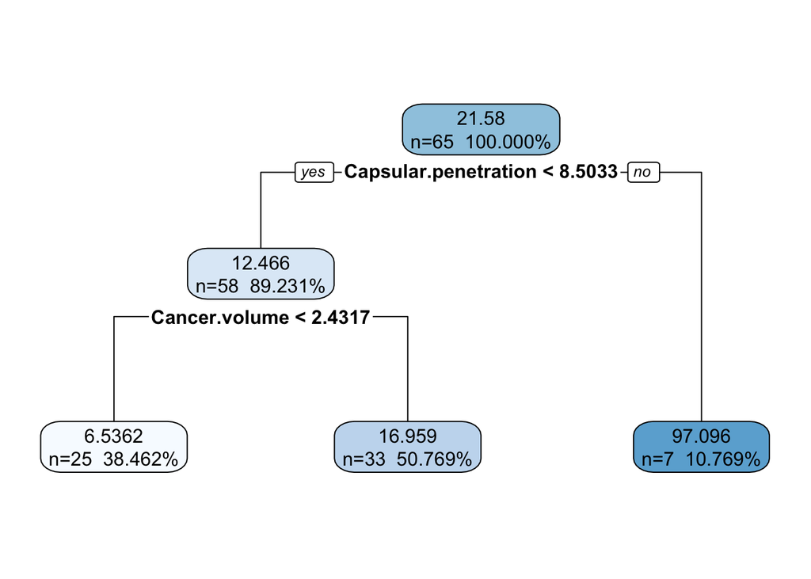

```r
# select sample of 65
set.seed(1023)
ind <- sample(nrow(prost), 65)
train2a <- prost[ind,]
test2a <- prost[-ind,]

# run tree
tree2a <- rpart(PSA.level~., data = train2a)
#tree2a
plot_tree2a <- rpart.plot(tree2a, digits = 5, fallen.leaves = TRUE, type = 2, extra = 101)
```

b-) Assess your model’s ability to predict and discuss its usefulness to the oncologists.

```r
# predict and get SSE, RSq using functions defined in Q1
pred2b <- predict(tree2a, test2a)

sse2b <- sse_fn(test2a$PSA.level, pred2b); sse2b
```

```
## [1] 69339.32
```

```r
rsq2b <- rsq_fn(test2a$PSA.level, pred2b); rsq2b
```

```
## [1] 0.2706765
```

This model has limited usefulness as seen by R2 = 0.27 on test set. This could be on account of limited training data. As we know, regression trees require large amounts of training data.

c-) Compare the performance of your regression tree model with that of the best regression model obtained in the problem 3 in the Homework 9. Which model is more easily interpreted and why?

This model has an Rsq of 0.27 while for Q3 HW9 we had Rsq of 0.3844 on test set. Given the limitation of data and that regression trees do nt allow us to determine the overall net effect of nidividual features we choose the Q3 HW9

## Problem 3

Refer to the Prostate cancer data set in the problem 3 in the Homework 9. Select a random sample of 65 observations to use as the model-building data set. (15 points, 5 each)

a-) Develop a neural network model for predicting PSA. Justify your choice of number of hidden nodes and penalty function weight and interpret your model.

```r
train3a <- train2a
test3a <- test2a

set.seed(1023)
nn3a <- neuralnet(PSA.level~., data = train3a, hidden = c(3,1), act.fct = 'tanh')
nn3a$result.matrix
```

```
##                                                   [,1]
## error                                     5.040883e+04
## reached.threshold                         8.690635e-03
## steps                                     1.290000e+02
## Intercept.to.1layhid1                    -6.765114e-01
## Cancer.volume.to.1layhid1                 1.641726e+00
## Weight.to.1layhid1                       -2.369903e-01
## Age.to.1layhid1                           9.579535e-01
## Benign.prostatic.hyperplasia.to.1layhid1 -8.514430e-01
## Seminal.vesicle.invasion.to.1layhid1     -3.593212e-01
## Capsular.penetration.to.1layhid1          8.978122e-01
## Gleason.score.to.1layhid1                -1.487564e+00
## Intercept.to.1layhid2                    -1.110195e+00
## Cancer.volume.to.1layhid2                 1.516328e+00
## Weight.to.1layhid2                       -1.336591e+00
## Age.to.1layhid2                           3.304064e+00
## Benign.prostatic.hyperplasia.to.1layhid2  4.986502e-01
## Seminal.vesicle.invasion.to.1layhid2      6.455275e-01
## Capsular.penetration.to.1layhid2         -8.331384e-03
## Gleason.score.to.1layhid2                 7.476748e-01
## Intercept.to.1layhid3                    -9.284088e-01
## Cancer.volume.to.1layhid3                 1.529543e+00
## Weight.to.1layhid3                        5.061324e-01
## Age.to.1layhid3                           6.122399e-01
## Benign.prostatic.hyperplasia.to.1layhid3  4.801788e-01
## Seminal.vesicle.invasion.to.1layhid3      2.434778e-01
## Capsular.penetration.to.1layhid3          9.986754e-01
## Gleason.score.to.1layhid3                 5.520866e-01
## Intercept.to.2layhid1                    -2.097590e+00
## 1layhid1.to.2layhid1                     -2.475344e+00
## 1layhid2.to.2layhid1                     -2.700506e+00
## 1layhid3.to.2layhid1                     -2.826751e+00
## Intercept.to.PSA.level                    1.029749e+01
## 2layhid1.to.PSA.level                    -1.150338e+01
```

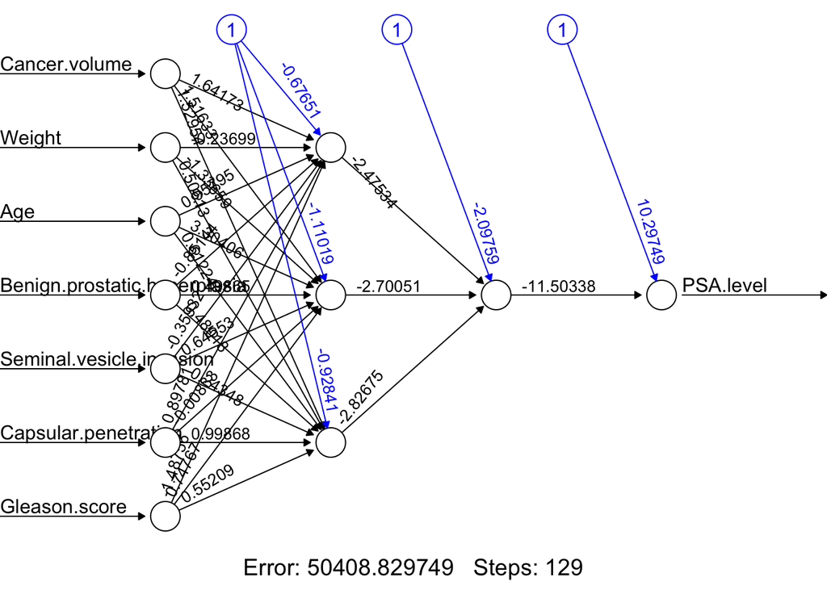

```r
plot(nn3a, rep = 'best')
```

```r
#pred3b <- compute(nn3a, test3a)
#pred3b$net.result
```

b-) Assess your model’s ability to predict and discuss its usefulness to the oncologists.

```r
pred3b <- compute(nn3a, test3a)
pred3b$net.result
```

```
##        [,1]
## 1  21.80087
## 9  21.80087
## 16 21.80087
## 21 21.80087
## 26 21.80087
## 27 21.80087
## 28 21.80087
## 29 21.80087
## 30 21.80087
## 33 21.80087
## 35 21.80087
## 41 21.80087
## 45 21.80087
## 46 21.80087
```

[output cut: 18 more lines]

The model has limited ability to predict and is not very useful.

c-) Compare the performance of your neural nerwork model with that of the best regression model obtained in the problem 3 in the Homework 9. Which model is more easily interpreted and why?

Given the model has limited ability to predict, we will prefer Q3 HW9.

## Problem 4

Refer to the Advertising Agency Data. Monthly data on amount of billings (Y, in thousands of constant dollars) and on number of hours of staff time (X, in thousand hours) for the 20 most recent months follow. A simple linear regression model is believed to be appropriate. but positively autocorrelated error terms may be present. (20 points 5 each)

a-) Fit a simple linear regression model by ordinary least squares and obtain the residuals. Conduct a formal test for positive autocorrelation using $\alpha$ = .01.

```r
adv <- read.csv('Advertising Agency.csv')
head(adv)
```

|  | Y | X |
| --- | --- | --- |
| 1 | 220.4 | 2.521 |
| 2 | 203.9 | 2.171 |
| 3 | 207.2 | 2.234 |
| 4 | 221.9 | 2.524 |
| 5 | 211.3 | 2.305 |
| 6 | 222.7 | 2.523 |

```r
str(adv)
```

```
## 'data.frame':    20 obs. of  2 variables:
##  $ Y: num  220 204 207 222 211 ...
##  $ X: num  2.52 2.17 2.23 2.52 2.31 ...
```

```r
reg2a <- lm(Y~X, data = adv)
summary(reg2a)
```

```
##
## Call:
## lm(formula = Y ~ X, data = adv)
##
## Residuals:
##      Min       1Q   Median       3Q      Max
## -1.55515 -0.23700  0.05229  0.56250  0.80657
##
## Coefficients:
##             Estimate Std. Error t value Pr(>|t|)
## (Intercept)  93.6865     0.8229   113.8   <2e-16 ***
## X            50.8801     0.2634   193.1   <2e-16 ***
## ---
## Signif. codes:  0 '***' 0.001 '**' 0.01 '*' 0.05 '.' 0.1 ' ' 1
##
## Residual standard error: 0.631 on 18 degrees of freedom
## Multiple R-squared:  0.9995, Adjusted R-squared:  0.9995
## F-statistic: 3.73e+04 on 1 and 18 DF,  p-value: < 2.2e-16
```

```r
ei2a <- reg2a$residuals

# Durbin Watson test for autocorrelation
dwtest(Y~X, data = adv)
```

```
##
##  Durbin-Watson test
##
## data:  Y ~ X
## DW = 0.97374, p-value = 0.002891
## alternative hypothesis: true autocorrelation is greater than 0
```

As can be seen p-value = 0.002891 there is autocorrelation present for alpha = 0.01

b-) Use a Cochrane-Orcutt procedure to estimate the model and test if the autocorrelation remains after the first iteration

```r
coch1_2b <- cochrane.orcutt(reg2a)
summary(coch1_2b)
```

```
## Call:
## lm(formula = Y ~ X, data = adv)
##
##             Estimate Std. Error t value  Pr(>|t|)
## (Intercept) 95.16377    0.91343  104.18 < 2.2e-16 ***
## X           50.46593    0.28415  177.61 < 2.2e-16 ***
## ---
## Signif. codes:  0 '***' 0.001 '**' 0.01 '*' 0.05 '.' 0.1 ' ' 1
##
## Residual standard error: 0.4514 on 17 degrees of freedom
## Multiple R-squared:  0.9995 ,  Adjusted R-squared:  0.9994
## F-statistic: 31543.9 on 1 and 17 DF,  p-value: < 3.137e-29
##
## Durbin-Watson statistic
## (original):    0.97374 , p-value: 2.891e-03
## (transformed): 1.96762 , p-value: 4.079e-01
```

As seen above autocorrelation is eliminated

c-) Restate the estimated regression function obtained in part (b) in terms of the original variables. Also obtain $s(b_0)$ and $s(b_1)$. Compare the estimated regression coefficients obtained.

Y = 95.16377 + 50.46593 * X

Standard error b0 = 0.91343; standard error b1 = 0.28415

d-)Staff time in month 21 is expected to be 3.625 thousand hours. Predict the amount of billings in constant dollars for month 21, using a 99 percent prediction intervaL Interpret your interval.

```r
yhat_4d <- 95.16377 + (50.46593 * 3.625); yhat_4d
```

```
## [1] 278.1028
```

```r
alpha = 1-0.99

#pred_l <- yhat_4d - qt(1-alpha/2, df = n-3)*spred; pred_l
#pred_u <- yhat_4d + qt(1-alpha/2, df = n-3)*spred; pred_u
```

## Problem 5

Refer to the Advertising Agency Data and Problem 4. (25 points, 5 points each)

a-) Use the Hildreth-Lu procedure to obtain a point estimate of the autocorrelation parameter. Do a search at the values $\rho$ = .1, .2, … , 1.0 and select from these the value of $\rho$ that minimizes SSE. Based on your model, obtain an estimate of the transformed regression function.

```r
prg1 <- function(x, y, rh) {
  # function to run  Hildreth-Lu method over grid for rh
  n <- length(rh)
  # define matrix
  out <- matrix(0, nrow = n, ncol = 2)
  # 1st column has rh value
  out[,1] <- rh
  for (i in 1:n){
    d <- anova(hildreth.lu(y = y, x = x, rho = rh[i]))
    # store sse result in 2nd column
    out[i,2] <- d$'Sum Sq'[2]
  }
  out
}

rh <- seq(0.1, 1, by = 0.1)
h1 <- prg1(adv$Y, x = adv$X, rh)

# return minimum value of rh and sse
h1[which.min(h1[,2]),]
```

```
## [1] 0.400000 3.468497
```

```r
rh_5a <- h1[which.min(h1[,2]),1]; rh_5a
```

```
## [1] 0.4
```

As seen above the minimum value of sse is for rh = 0.4. We use this to obtain an estimate of the transformed regression function

```r
ytnew = adv$Y - rh_5a*Lag(adv$Y, shift = 1)
xtnew = adv$X - rh_5a*Lag(adv$X, shift = 1)

# regress new values
reg5a <- lm(ytnew~xtnew)
summary(reg5a)
```

```
##
## Call:
## lm(formula = ytnew ~ xtnew)
##
## Residuals:
##      Min       1Q   Median       3Q      Max
## -0.94217 -0.31722 -0.00313  0.36413  0.61919
##
## Coefficients:
##             Estimate Std. Error t value Pr(>|t|)
## (Intercept)  57.0406     0.5329   107.0   <2e-16 ***
## xtnew        50.4925     0.2770   182.3   <2e-16 ***
## ---
## Signif. codes:  0 '***' 0.001 '**' 0.01 '*' 0.05 '.' 0.1 ' ' 1
##
## Residual standard error: 0.4517 on 17 degrees of freedom
##   (1 observation deleted due to missingness)
## Multiple R-squared:  0.9995, Adjusted R-squared:  0.9995
## F-statistic: 3.324e+04 on 1 and 17 DF,  p-value: < 2.2e-16
```

```r
# check for autocorrelation using DW Test
dwtest(reg5a)
```

```
##
##  Durbin-Watson test
##
## data:  reg5a
## DW = 1.9054, p-value = 0.3509
## alternative hypothesis: true autocorrelation is greater than 0
```

DW Test shows that no autocorrelation present. The transformed regression function is stated as

Y’ = 57.0406 + 50.4925 * X’

b-) Use the first difference procedure to obtain a point estimate of the autocorrelation parameter. Based on your model, obtain an estimate of the transformed regression function.

```r
# First Difference

# assume rho = 1 & calculate lag
rho = 1
ytnew = adv$Y - rho*Lag(adv$Y, shift = 1)
xtnew = adv$X - rho*Lag(adv$X, shift = 1)

# perform regression
f1 <- lm(ytnew~xtnew - 1)
summary(f1)
```

```
##
## Call:
## lm(formula = ytnew ~ xtnew - 1)
##
## Residuals:
##     Min      1Q  Median      3Q     Max
## -0.8016 -0.1744  0.1508  0.4578  1.0575
##
## Coefficients:
##       Estimate Std. Error t value Pr(>|t|)
## xtnew   50.164      0.425     118   <2e-16 ***
## ---
## Signif. codes:  0 '***' 0.001 '**' 0.01 '*' 0.05 '.' 0.1 ' ' 1
##
## Residual standard error: 0.5787 on 18 degrees of freedom
##   (1 observation deleted due to missingness)
## Multiple R-squared:  0.9987, Adjusted R-squared:  0.9986
## F-statistic: 1.393e+04 on 1 and 18 DF,  p-value: < 2.2e-16
```

The transformed regression function is stated as

Y’ = 50.164 X’

c-) Test whether any positive autocorrelation remains in the transformed regression model for both part a and b; use $\alpha$ = .01. State the alternatives, decision rule, and conclusion.

```r
# check using DW
dwtest(f1)
```

```
##
##  Durbin-Watson test
##
## data:  f1
## DW = 2.182, p-value = 0.7493
## alternative hypothesis: true autocorrelation is greater than 0
```

Ho : No autocorrelation; Ha: There is autocorrelation

As seen above, p-value of 0.7493 indicates that there is no autocorrelation.

d-) Which method would you choose? Explain your rationale

both models have similar results. We choose the Hildreth Lu method since it iterates over a range of values before determining rho as opposed to first difference where rho = 1 is assumed.

e-) For the selected model in part d. Staff time in month 21 is expected to be 3.625 thousand hours. Predict the amount of billings in constant dollars for month 21, using a 99 percent prediction interval. Interpret your interval.

```r
ytnew = adv$Y - rh_5a*Lag(adv$Y, shift = 1)
xtnew = adv$X - rh_5a*Lag(adv$X, shift = 1)

# regress new values
reg5a <- lm(ytnew~xtnew)
summary(reg5a)
```

```
##
## Call:
## lm(formula = ytnew ~ xtnew)
##
## Residuals:
##      Min       1Q   Median       3Q      Max
## -0.94217 -0.31722 -0.00313  0.36413  0.61919
##
## Coefficients:
##             Estimate Std. Error t value Pr(>|t|)
## (Intercept)  57.0406     0.5329   107.0   <2e-16 ***
## xtnew        50.4925     0.2770   182.3   <2e-16 ***
## ---
## Signif. codes:  0 '***' 0.001 '**' 0.01 '*' 0.05 '.' 0.1 ' ' 1
##
## Residual standard error: 0.4517 on 17 degrees of freedom
##   (1 observation deleted due to missingness)
## Multiple R-squared:  0.9995, Adjusted R-squared:  0.9995
## F-statistic: 3.324e+04 on 1 and 17 DF,  p-value: < 2.2e-16
```

```r
mse <- summary(reg5a)$sigma^2

# get intercept
b0 <- summary(reg5a)[[4]][1,1]/(1-rh_5a); b0
```

```
## [1] 95.0676
```

```r
s_bo <- summary(reg5a)[[4]][1,2]/(1-rh_5a); s_bo
```

```
## [1] 0.8881203
```

```r
# get coefficient
b1 <- summary(reg5a)[[4]][2,1]; b1
```

```
## [1] 50.49249
```

```r
s_b1 <- summary(reg5a)[[4]][2,2]; s_b1
```

```
## [1] 0.2769661
```

```r
yhat_correct <- b0 + b1*adv$X
yhat_correct
```

```
##  [1] 222.3592 204.6868 207.8678 222.5106 211.4528 222.4601 247.5549 247.2520
##  [9] 273.4071 269.8221 283.7580 286.9895 275.6287 276.1337 269.1152 232.5586
## [17] 247.5044 252.4527 278.0019 277.7494
```

```r
# Point Forecasts
xn_plus1 <- 3.625
xn <- rev(adv$X)[1]; xn
```

```
## [1] 3.618
```

```r
yhat_nplus1 <- b0+b1*xn_plus1; yhat_nplus1
```

```
## [1] 278.1029
```

```r
yn <- rev(adv$Y)[1]; yn
```

```
## [1] 278.5
```

```r
en <- yn - (b0+b1*xn); en
```

```
## [1] 0.750577
```

```r
yhat_forecast_nplus1 <- yhat_nplus1 + rho*en
yhat_forecast_nplus1
```

```
## [1] 278.8534
```

```r
# Forecast Interval
xprime <- xtnew
xbar_prime <- mean(xprime[-1]) # drop 1st value which is NA
xn_plus1_prime <- xn_plus1 - rho*xn

alpha = 0.05
n <- length(adv$Y)

spred <- sqrt(mse*(1 + (1/n) + (xn_plus1_prime - xbar_prime)^2/(sum((xprime[-1]-xbar_prime)^2))))
spred
```

```
## [1] 0.6967224
```

```r
pred_l <- yhat_forecast_nplus1 - qt(1-alpha/2, df = n-3)*spred; pred_l
```

```
## [1] 277.3835
```

```r
pred_u <- yhat_forecast_nplus1 + qt(1-alpha/2, df = n-3)*spred; pred_u
```

```
## [1] 280.3234
```